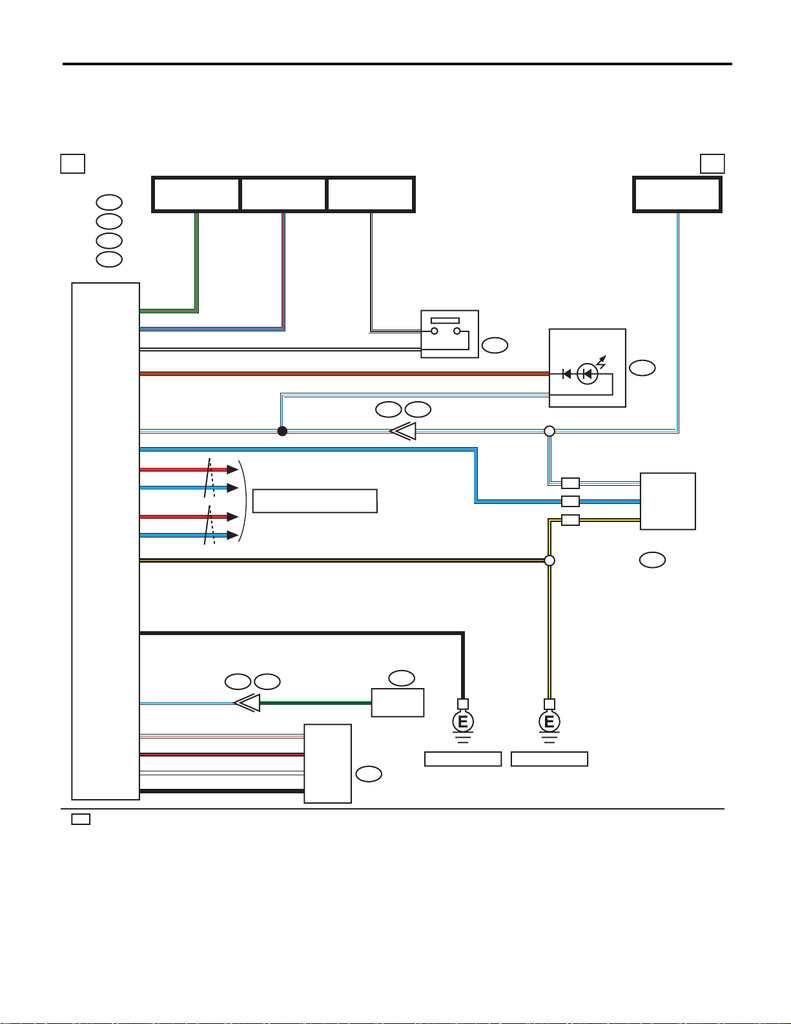

WI-259

Immobilizer System

WIRING SYSTEM

27.Immobilizer System

A: WIRING DIAGRAM

1. ENGINE TYPE FA (WITHOUT PUSH BUTTON START)

WI-44458

B555

3

14

1a 1a

SC

B415

B559

i229 B551

B22 E3

SC

SC

SC

A: B280

B281

C: i84

D: i171

B:

B

i10

W/L

E158B:

B3

B/WA4

BR/R BR/RD26

40

1

W/LC6

LA21

B/YA1

2

1

L/R

B7

W/B

B/W

W/B

BC1

A31

RB20

LB28

W/L

W/RB10

B/RB22

G/B B43

WB2

BB30

5W/R

4B/R

1W

7B

B/Y

RC27

LC35

G/R

G/R

L/R

B/Y 5

L3

W/L 1

W/L

W/L

W/L

ECM

: WITH SECURITY CM

SECURITY

CM

SECURITY/

IMMOBILIZER

COMBINATION METER

MB-28

M/B FUSE NO. 14

(B)

FB-38

F/B FUSE NO. 12

(IG)

MB-29

M/B FUSE NO. 8

(B)

KEY WARNING

SWITCH

REF. TO CAN COMMUNICATION

SYSTEM [b]

IMMOBILIZER

ANTENNA

FB-18

F/B FUSE NO. 7

(B)

REF. TO GND [c]REF. TO GND [e]

BODY INTEGRATED UNIT

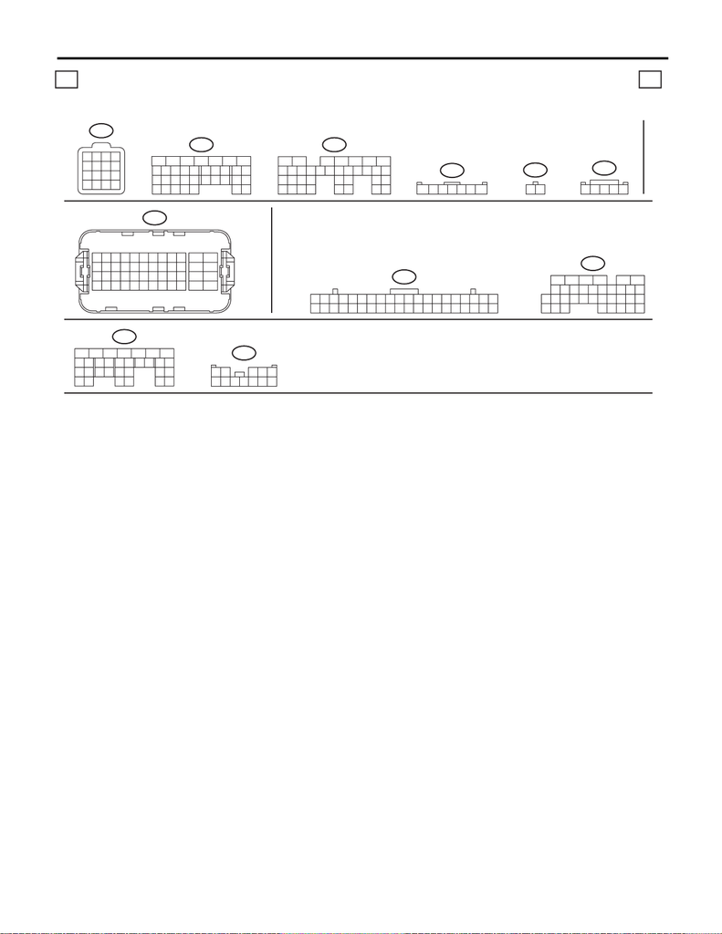

WI-260

Immobilizer System

WIRING SYSTEM

LIST OF CONNECTORS

1b 1b

WI-44459

i10

i171

D:

i84

C:

B:

B281

B555

B415

(B)

i229

B280

A:

B22

(BR)

(B)

B:

E158

B559

12

3

4

5678

9

10 11 12

1413 15 16

5672134

29

10 11 12 13 14 15

2524

16

30

98

17 18 19

20

28

21 22 23

3231

26 27

33 34 35

18

2719 20 21 22

23

26

24

25

28 29 3332 3430 31

98

15

1413121110

17

16

1234567

12345

6

7

12 1

2

345

79

10

85

23

11 12

6

19 21 222017

24

35 36

47 48

18

31 33 343229 30

43 45 464441 42

3412

15 1613 14

27 2825 26

39 4037 38

11 12

9

10

7856341

2

15 1613 14 19

18

20

21 22 23 24 26

25

27 28 29 30 31 32 33 34 35 36 37 38 39 40

17 19

18

21

20

2322 24 25 26

17

1

23

4

56

27

28 29 30

31 32 33 34 35

798

151413121110 16

19

18

20 21

22

23

26

24

25

27

28 29

30 31

98

15

1413121110

17

16

1234567

12 345

6789

10 11 12

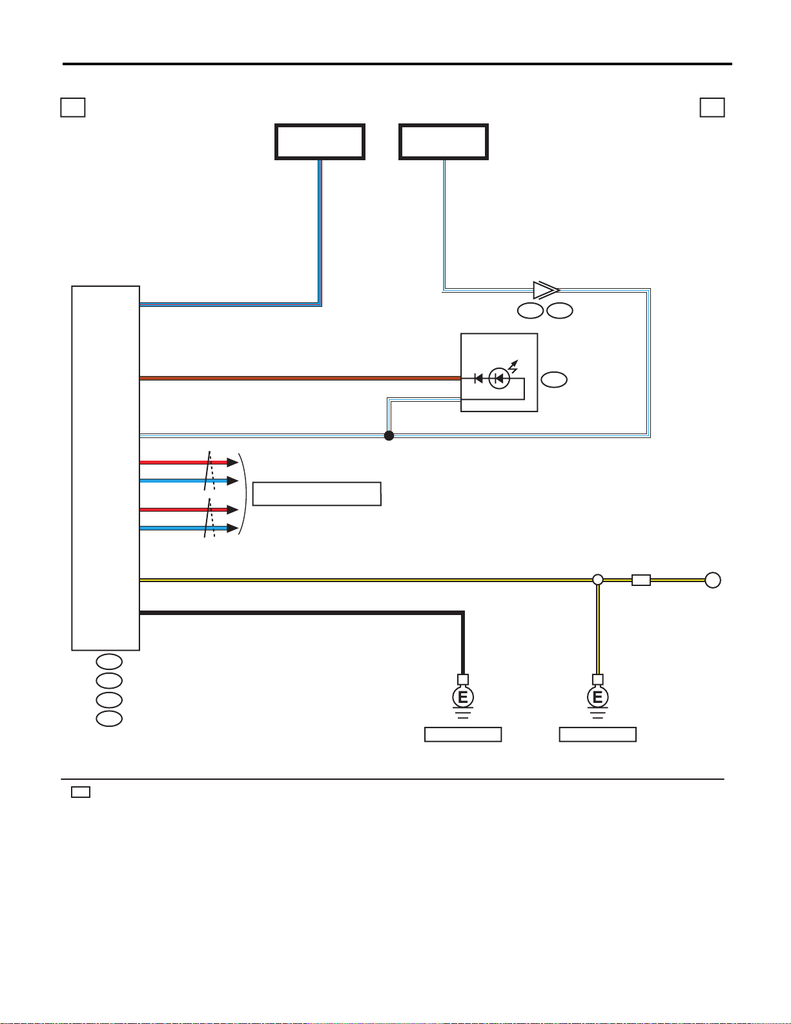

WI-261

Immobilizer System

WIRING SYSTEM

2. ENGINE TYPE FA (WITH PUSH BUTTON START)

WI-44460

3

2a 2a

i10

B551 i229

A: B280

B281

C: i84

D: i171

B:

B/Y

B

W/L

BR/R BR/RD26

40

1

W/LC6

B7

W/L

RB20

LB28

C1 B

RC27

LC35

L/R

L/R

W/L

W/L

B/YA1

B/Y

A

ID

SECURITY/

IMMOBILIZER

COMBINATION

METER

BODY INTEGRATED UNIT

FB-18

F/B FUSE NO. 7

(B)

MB-29

M/B FUSE NO. 8

(B)

REF. TO GND [c]REF. TO GND [e]

REF. TO CAN COMMUNICATION

SYSTEM [b]

: WITH ID CODE BOX

ID

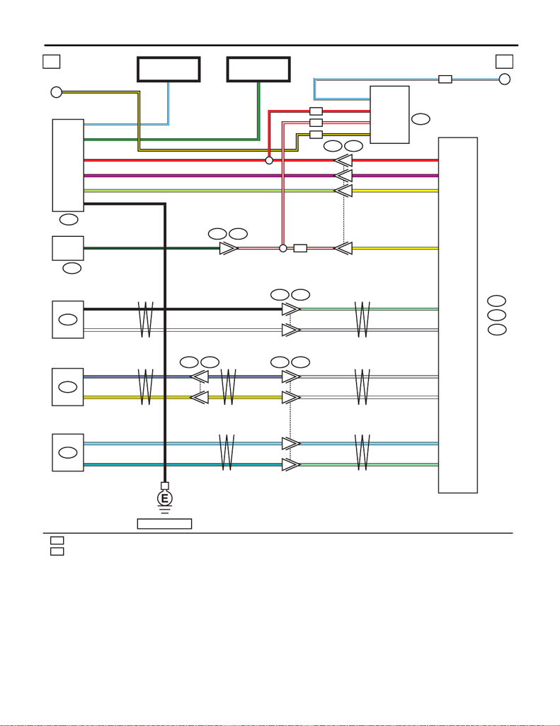

WI-262

Immobilizer System

WIRING SYSTEM

2

7

WI-44461

2

15

6

19

14

E158B:

1

6

2b 2b

AD12

R298

R297

B424

B574C:

B573B:

B572A:

B422

B575 B576

E3 B22

SB

B9

1SB

SB

SB

LG B83 L/G

L/G

LG

R5 B92

1

2

AD11 B579

ND

ID

B43

G/B

G/B

R

C17

GR/L 1

V

C26

Y

C29

LG

C3

GR

LG

GR

C2

GR

B11

W

B10

1

3

1

3

B

W

L/R

Y/L

W/L

B/Y

W/L

7

G/R

G/R

6

B

1

Y

A13

B/Y 5

R

5

V

4

Y/L

3

R

V

Y/L

R/WR/W Y

Y/L

W

L/R

GR

ECM

GR/LGR/L

B

ID

ID

A

ND

7

8

R82 R81

R2

ID

R/W 4

ID

STEERING

LOCK CM

KEYLESS ACCESS

INTERIOR ANTENNA

(CENTER)

KEYLESS ACCESS

INTERIOR ANTENNA

(REAR)

KEYLESS ACCESS

INTERIOR ANTENNA

(FRONT)

KEYLESS ACCESS CM

ID CODE BOX

: WITH ID CODE BOX

: WITHOUT ID CODE BOX

FB-43

F/B FUSE NO. 32

(IG)

FB-18

F/B FUSE NO. 7

(B)

B

REF. TO GND [d]

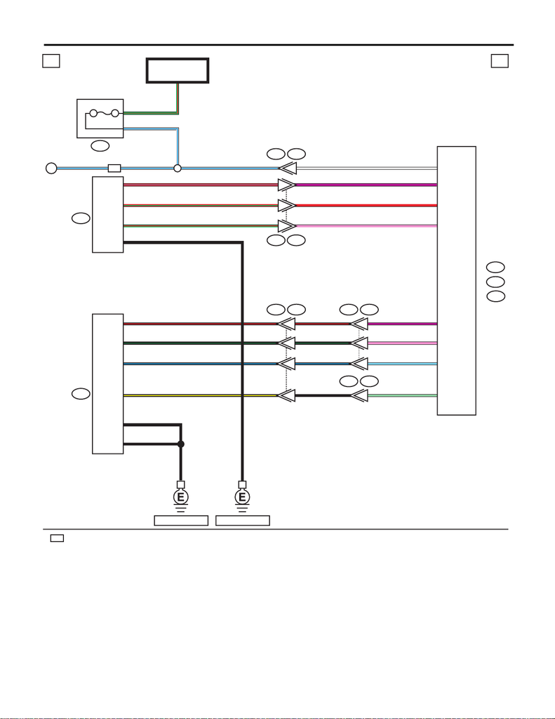

WI-263

Immobilizer System

WIRING SYSTEM

R296

i150

WI-44462

17

16

18

15

B574C:

B573B:

B572A:

5

9

2c 2c

B

i231 B553

8

4

9

14

B23 B28

B575 B576

R5 B92

VB5

R B17

V

RR/G

G/R

4

5

P B19P2

1

R/G

G/R

R/L R/L

B

B

B

VC9

PC7

9

10

SB C114

B/R

B/G

B/L

LG C248 B/Y

B/R

B/G

B/L

B/Y

4B

5B

4

GR/L GR/L GR/L WWA2

B/R

B/G

B/L

B

MB-35

SBF-8

(B)

ID : WITH ID CODE BOX

3

B575 B576

ID

7.5A

B550

10 G/R

GR/L25

KEYLESS ACCESS CM

REF. TO GND [f]REF. TO GND [e]

PUSH BUTTON

IGNITION

SWITCH

RECEIVER

FUSE HOLDER

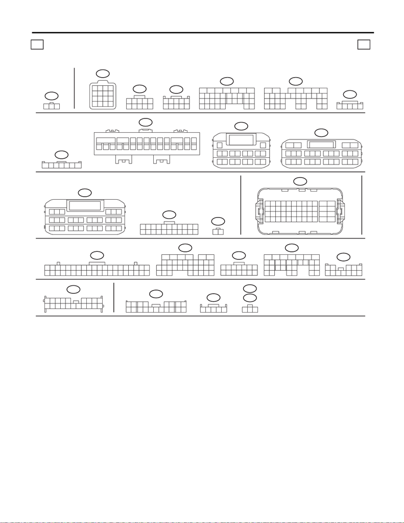

WI-264

Immobilizer System

WIRING SYSTEM

LIST OF CONNECTORS

FUSE HOLDER

2d 2d

12

3

4

5678

9

10 11 12

1413 15 16

91078

5

6

34

21

5672134

29

10 11 12 13 14 15

2524

16

30

98

17 18 19

20

28

21 22 23

3231

26 27

33 34 35

18

2719 20 21 22

23

26

24

25

28 29 3332 3430 31

98

15

1413121110

17

16

1234567

1 2345

6

7

1

2

345

91

2

232221 262524201918

4

13

12

17

3

16

6

15

587

14

10 11

11 12

34

13 14

56

15 16

78

17 18

10

9

12

123

456789

10 11

12 13 14 15 16 17 18 19 20 21 22

21

79

10

85

23

11 12

6

19 21 222017

24

35 36

47 48

18

31 33 343229 30

43 45 464441 42

3412

15 1613 14

27 2825 26

39 4037 38

11 12

9

10

7856341

2

15 1613 14 19

18

20

21 22 23 24 26

25

27 28 29 30 31 32 33 34 35 36 37 38 39 40

17

19

18

21

20

2322 24 25 26

17

1

23

4

56

27

28 29 30

31 32 33 34 35

798

151413121110 16

3

42

156

7

13 1411

12

9

10

8

19

18

20 21

22

23

26

24

25

27

28 29

30 31

98

15

1413121110

17

16

1234567

12 345

6789

10 11 12

12345 6789

10 11 12 13 14 15 16 17 18 19 20

1

9

234 5678

10 11 12 14 15 16 17 18 1913

3

421

5

123

123

WI-44463

i10

i171

D:

i84

C:

B:

B281

B424

(B)

B422

B575

R298

R297

B280

A:

A:

B572

B22

(BR)

AD12

B92

B550

(B)

B579

i229

i231

R82

(B)

R296

(B)

B:

E158

i150

B23

10

12345

6789

B573B:

17 18 19 20 21 22 23 24 25 26 27 28

567 89

10 11 12 13 14 15 16

12 34

B574C:

19 20 21 22 23 24 25 26 27 28 29 30

789

10 11 12 13 14 15 16 17 18

123 456

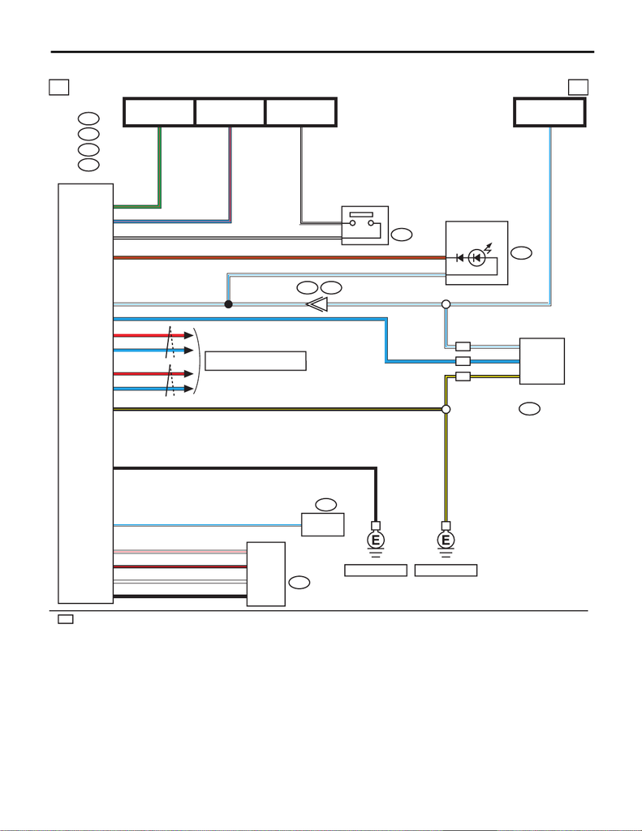

WI-265

Immobilizer System

WIRING SYSTEM

3. ENGINE TYPE EJ (WITHOUT PUSH BUTTON START)

WI-44464

B555

3

3a 3a

SC

B415

B559

i229 B551

SC

SC

SC

A: B280

B281

C: i84

D: i171

B:

B

i10

W/L

B135B:

B3

B/WA4

BR/R BR/RD26

40

1

W/LC6

LA21

B/YA1

2

1

L/R

B7

W/B

B/W

W/B

BC1

A31

RB20

LB28

W/L

W/RB10

B/RB22

W/L B25

WB2

BB30

5W/R

4B/R

1W

7B

B/Y

RC27

LC35

G/R

G/R

L/R

B/Y 5

L3

W/L 1

W/L

W/L

W/L

ECM

: WITH SECURITY CM

SECURITY

CM

SECURITY/

IMMOBILIZER

COMBINATION METER

MB-28

M/B FUSE NO. 14

(B)

FB-38

F/B FUSE NO. 12

(IG)

MB-29

M/B FUSE NO. 8

(B)

KEY WARNING

SWITCH

REF. TO CAN COMMUNICATION

SYSTEM [b]

IMMOBILIZER

ANTENNA

FB-18

F/B FUSE NO. 7

(B)

REF. TO GND [c]REF. TO GND [e]

BODY INTEGRATED UNIT

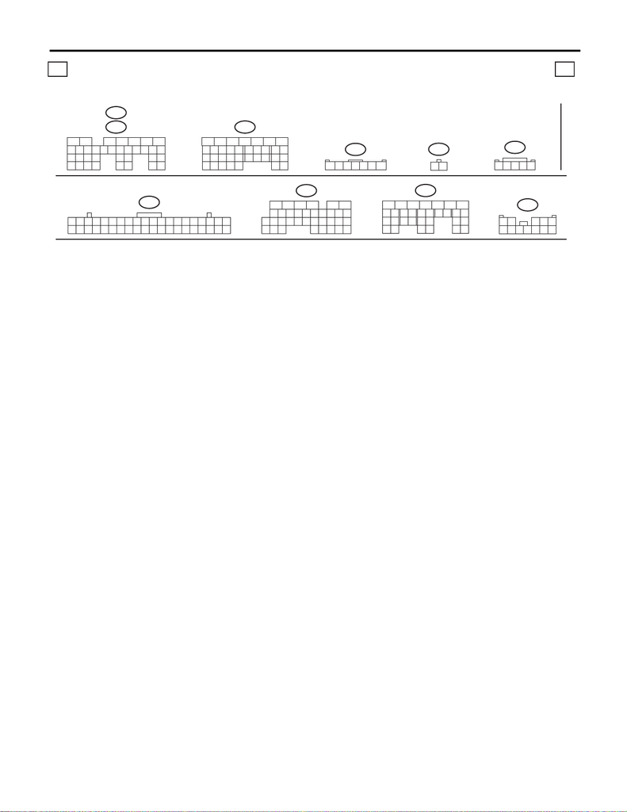

WI-266

Immobilizer System

WIRING SYSTEM

LIST OF CONNECTORS

3b 3b

5672134

29

10 11 12 13 14 15

2524

16

30

98

17 18 19

20

28

21 22 23

3231

26 27

33 34 35

18

2719 20 21 22

23

26

24

25

28 29 3332 3430 31

98

15

1413121110

17

16

1234567

12345

6

7

12

1

2

345

11 12

9

10

7856341

2

15 1613 14 19

18

20

21 22 23 24 26

25

27 28 29 30 31 32 33 34 35 36 37 38 39 40

17 19

18

21

20

2322 24 25 26

17

1

23

4

56

27

28 29 30

31 32 33 34 35

798

151413121110 16

19

18

20 21

22

23

26

24

25

27

28 29

30 31

98

15

1413121110

17

16

1234567

12 345

6789

10 11 12

WI-44465

i10

i171

D:

i84

C:

B555

B415

(B)

i229

B:

B281

B: B135

B280

A:

B559

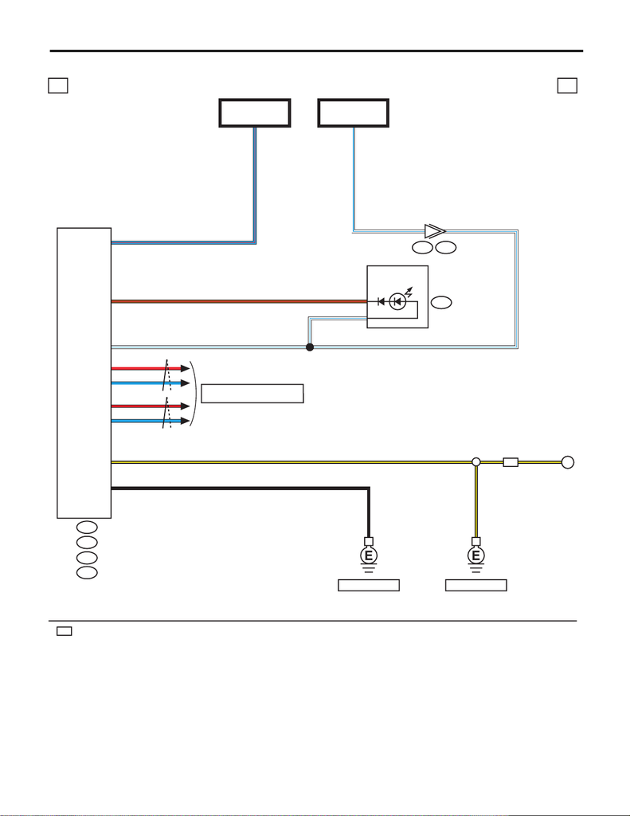

WI-267

Immobilizer System

WIRING SYSTEM

4. ENGINE TYPE EJ (WITH PUSH BUTTON START)

WI-44466

3

4a 4a

i10

B551 i229

A: B280

B281

C: i84

D: i171

B:

B/Y

B

W/L

BR/R BR/RD26

40

1

W/LC6

B7

W/L

RB20

LB28

C1 B

RC27

LC35

L/R

L/R

W/L

W/L

B/YA1

B/Y

A

ID

SECURITY/

IMMOBILIZER

COMBINATION

METER

BODY INTEGRATED UNIT

FB-18

F/B FUSE NO. 7

(B)

MB-29

M/B FUSE NO. 8

(B)

REF. TO GND [c]REF. TO GND [e]

REF. TO CAN COMMUNICATION

SYSTEM [b]

: WITH ID CODE BOX

ID

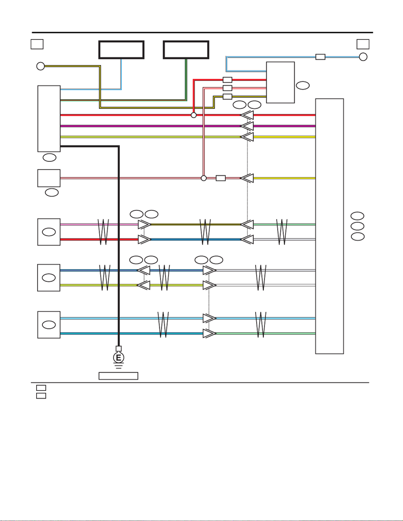

WI-268

Immobilizer System

WIRING SYSTEM

2

7

WI-44467

2

15

6

19

B135B:

1

6

4b 4b

AD12

R298

R297

B424

B574C:

B573B:

B572A:

B422

B575 B576

SB

B9

1SB

SB

SB

LG B83 L/G

L/G

LG

R5 B92

3

9

AD13 B4

ND

ID

B25

R/W

R

C17

GR/L 1

V

C26

Y

C29

LG

C3

GR

LG

GR

C2

GR

B11

W

B10

1

3

1

3

P

R

Y/B

L/B

L/R

Y/L

W/L

B/Y

W/L

7

G/R

G/R

6

B

1

Y

R

V

Y

Y

A13

B/Y 5

R

5

V

4

Y/L

3

R

V

Y/L

R/W

Y/L

W

L/R

GR

ECM

GR/LGR/L

B

ID

ID

A

ND

7

8

R82 R81

8

22

R2

ID

R/W 4

ID

STEERING

LOCK CM

KEYLESS ACCESS

INTERIOR ANTENNA

(CENTER)

KEYLESS ACCESS

INTERIOR ANTENNA

(REAR)

KEYLESS ACCESS

INTERIOR ANTENNA

(FRONT)

KEYLESS ACCESS CM

ID CODE BOX

: WITH ID CODE BOX

: WITHOUT ID CODE BOX

FB-43

F/B FUSE NO. 32

(IG)

FB-18

F/B FUSE NO. 7

(B)

B

REF. TO GND [d]

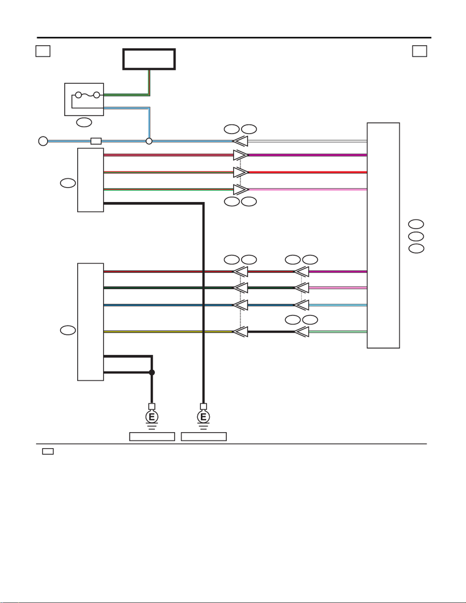

WI-269

Immobilizer System

WIRING SYSTEM

R296

i150

WI-44468

17

16

18

15

B574C:

B573B:

B572A:

5

9

4c 4c

B

i231 B553

8

4

9

14

B23 B28

B575 B576

R5 B92

VB5

R B17

V

RR/G

G/R

4

5

P B19P2

1

R/G

G/R

R/L R/L

B

B

B

VC9

PC7

9

10

SB C114

B/R

B/G

B/L

LG C248 B/Y

B/R

B/G

B/L

B/Y

4B

5B

4

GR/L GR/L GR/L WWA2

B/R

B/G

B/L

B

MB-35

SBF-8

(B)

ID : WITH ID CODE BOX

3

B575 B576

ID

7.5A

B550

11 G/R

GR/L26

KEYLESS ACCESS CM

REF. TO GND [f]REF. TO GND [e]

PUSH BUTTON

IGNITION

SWITCH

RECEIVER

FUSE HOLDER

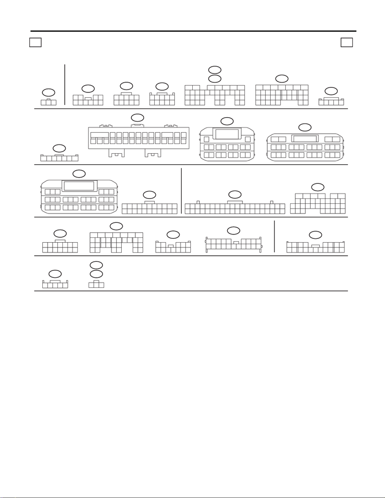

WI-270

Immobilizer System

WIRING SYSTEM

LIST OF CONNECTORS

FUSE HOLDER

4d 4d

5672134

29

10 11 12 13 14 15

2524

16

30

98

17 18 19

20

28

21 22 23

3231

26 27

33 34 35

18

2719 20 21 22

23

26

24

25

28 29 3332 3430 31

98

15

1413121110

17

16

1234567

1 2345

6

7

8765

21

10

9

43

10

12345

6789

91078

5

6

34

21

1

2

345

11 12

34

13 14

56

15 16

78

17 18

10

9

12

123

456789

10 11

12 13 14 15 16 17 18 19 20 21 22

11 12

9

10

7856341

2

15 1613 14 19

18

20

21 22 23 24 26

25

27 28 29 30 31 32 33 34 35 36 37 38 39 40

17

19

18

21

20

2322 24 25 26

17

1

23

4

56

27

28 29 30

31 32 33 34 35

798

151413121110 16

3

42

156

7

13 1411

12

9

10

8

19

18

20 21

22

23

26

24

25

27

28 29

30 31

98

15

1413121110

17

16

1234567

12 345

6789

10 11 12

12345 6789

10 11 12 13 14 15 16 17 18 19 20

1

9

234 5678

10 11 12 14 15 16 17 18 1913

3

421

5

123

101

242322 272625212019

5

14

13

18

432

17

7

16

698

15

11 12

123

WI-44469

i10

i171

D:

i84

C:

B424

(B)

i229

B422

B4

(B)

AD12

B23

B92

B:

B281

B: B135

R296

B575

R298

R297

B280

A:

A:

B572

i231

(B)

R82

i150

(B)

B550

B573B:

17 18 19 20 21 22 23 24 25 26 27 28

567 89

10 11 12 13 14 15 16

12 34

B574C:

19 20 21 22 23 24 25 26 27 28 29 30

789

10 11 12 13 14 15 16 17 18

123 456